# (3.12) Exercise:

1. Download Haberman Cancer Survival dataset from Kaggle. You may have to create a Kaggle account to donwload data. (https://www.kaggle.com/gilsousa/habermans-survival-data-set)
2. Perform a similar alanlaysis as above on this dataset with the following sections:
- High level statistics of the dataset: number of points, numer of features, number of classes, data-points per class.
- Explain our objective.
- Perform Univaraite analysis(PDF, CDF, Boxplot, Voilin plots) to understand which features are useful towards classification.
- Perform Bi-variate analysis (scatter plots, pair-plots) to see if combinations of features are useful in classfication.
- Write your observations in english as crisply and unambigously as possible. Always quantify your results.

### About the dataset

The dataset contains cases from a study that was conducted between 1958 and 1970 at the University of Chicago's Billings Hospital on the survival of patients who had undergone surgery for breast cancer.

source - https://www.kaggle.com/gilsousa/habermans-survival-data-set/data

Attributes:

1.Age of patient at time of operation  
2.Patient's year of operation  
3.Number of positive axillary nodes detected  
4.Survival status (class attribute): 1= the patient survived 5 years or longer. 2= the patient died within 5 year

*Objectice*

To explore the Haberman Cancer Survival Dataset and find which feature or combination of feature are helpfull in determining the status of a person in 5 years after the operation.

```python
import pandas as pd
import numpy as np
import matplotlib.pyplot as plt
import seaborn as sns
import warnings
warnings.filterwarnings('ignore')
#Load Haberman Dataset to a pandas dataframe

haberman = pd.read_csv("haberman.csv")
```

```python
# (Q) how many data-points and features?
haberman.shape
```

```
(305, 4)
```

```python
#(Q) What are the column names in our dataset?
haberman.columns
```

```
Index(['30', '64', '1', '1.1'], dtype='object')
```

```python
#Columns changed
haberman.columns = ['age', 'operation_year', 'axil_nodes', 'survived_status']
```

```python
haberman.columns
```

```
Index(['age', 'operation_year', 'axil_nodes', 'survived_status'], dtype='object')
```

```python
haberman['survived_status'].value_counts()
```

```
1    224
2     81
Name: survived_status, dtype: int64
```

```python
haberman.info()
```

```
<class 'pandas.core.frame.DataFrame'>
RangeIndex: 305 entries, 0 to 304
Data columns (total 4 columns):
age                305 non-null int64
operation_year     305 non-null int64
axil_nodes         305 non-null int64
survived_status    305 non-null int64
dtypes: int64(4)
memory usage: 9.6 KB
```

```python
haberman.describe()
```

|  | age | operation_year | axil_nodes | survived_status |
| --- | --- | --- | --- | --- |
| count | 305.000000 | 305.000000 | 305.000000 | 305.000000 |
| mean | 52.531148 | 62.849180 | 4.036066 | 1.265574 |
| std | 10.744024 | 3.254078 | 7.199370 | 0.442364 |
| min | 30.000000 | 58.000000 | 0.000000 | 1.000000 |
| 25% | 44.000000 | 60.000000 | 0.000000 | 1.000000 |
| 50% | 52.000000 | 63.000000 | 1.000000 | 1.000000 |
| 75% | 61.000000 | 66.000000 | 4.000000 | 2.000000 |
| max | 83.000000 | 69.000000 | 52.000000 | 2.000000 |

Observations:  
1) Dataset has 4 features/variable and 305 data points.

2) Patient's age lie between 30-83 years those who had undergone cancer surgery in year 1958-1969.

3) 0-4 axil nodes: 75% patient,0 node: 25% patient and very few had up to 52 axil nodes.

4) The dataset has 224 datapoint labeled as "1" and 81 datapoint labeled as "2" viz.,Surv_status:"1=Survived(the patient survived 5 years or longer)", "2=Died(the patient died within 5 year)". Therefore, the dataset is an imbalance dataset

## 2-D Scatter Plot

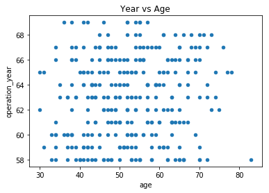

```python
haberman.plot(kind='scatter', x='age', y='operation_year', title='Year vs Age')
```

Relation between age and year is not clearly visible with this plot

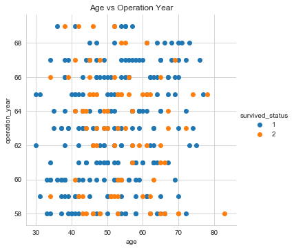

```python
# 2-D Scatter plot with color-coding
sns.set_style('whitegrid')
sns.FacetGrid(haberman, hue='survived_status', size=5) \
    .map(plt.scatter,'age', 'operation_year').add_legend()
plt.title('Age vs Operation Year')
```

Classification is not possible based on year or age realtionship

### Pair Plots

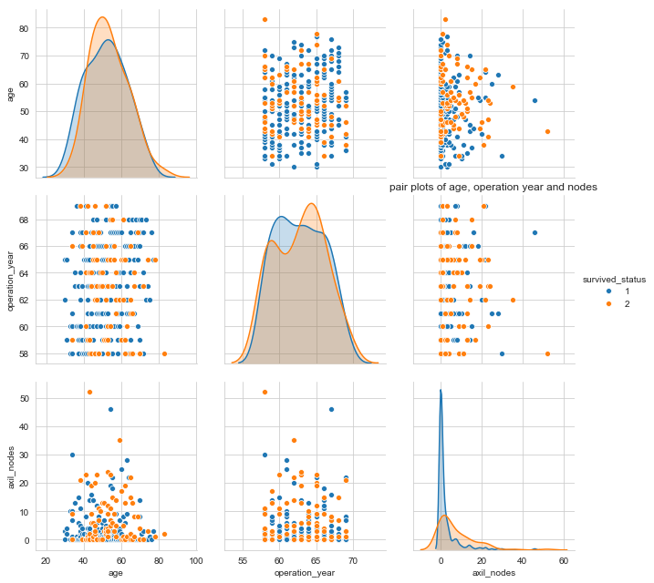

```python
sns.set_style('whitegrid')
sns.pairplot(haberman, hue='survived_status', vars = ['age', 'operation_year', 'axil_nodes'] , size=3)
plt.title("pair plots of age, operation year and nodes")
```

[output not shown]

### Histogram, PDF, CDF

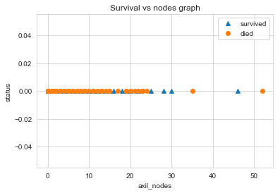

```python
survived = haberman[haberman['survived_status'] == 1]
not_survived = haberman[haberman['survived_status'] == 2]
plt.plot(survived['axil_nodes'],  np.zeros_like(survived['axil_nodes']),'^',label='survived')
plt.plot(not_survived['axil_nodes'],  np.zeros_like(not_survived['axil_nodes']),'o',label = 'died')
plt.xlabel("axil_nodes");
plt.ylabel("status");
plt.legend();
plt.title("Survival vs nodes graph");
```

Majority of the points are overlapping, hence it is difficult to draw conclusion on this variable

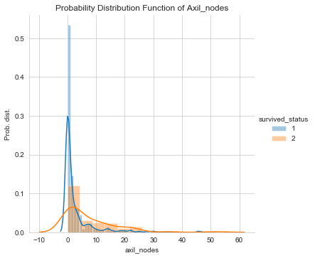

```python
sns.FacetGrid(haberman, hue='survived_status', height=5)\
    .map(sns.distplot, 'axil_nodes')\
    .add_legend()
plt.ylabel('Prob. dist.')
plt.title('Probability Distribution Function of Axil_nodes')
```

We can observe that with 0-3 axil nodes, the chances of survival is more.

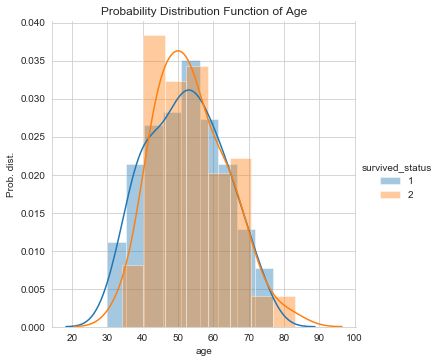

```python
sns.FacetGrid(haberman, hue='survived_status', height=5)\
    .map(sns.distplot, 'age')\
    .add_legend()
plt.ylabel('Prob. dist.')
plt.title('Probability Distribution Function of Age')
```

1) The data is overlapping hence no major information can be inferred.  
2) Patients with age less than 40 yrs. has higher chance to survive and patient with age more than 78 yrs are most likely to die within 5 yrs. of surgery

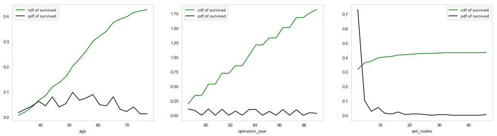

```python
# pdf and cdf of survived
plt.figure(figsize=(20,5))
i=1
for column in (list(haberman.columns)[:-1]):
    plt.subplot(1,3,i)
    counts, bin_edges = np.histogram(survived[column], bins=20, density=True)
    pdf = counts/sum(counts)
    cdf = np.cumsum(counts)
    plt.plot(bin_edges[1:], cdf, label='cdf of survived', color='green')
    plt.plot(bin_edges[1:], pdf, label = 'pdf of survived', color='black')
    plt.xlabel(column)
    plt.grid()
    plt.legend()
    i+=1
```

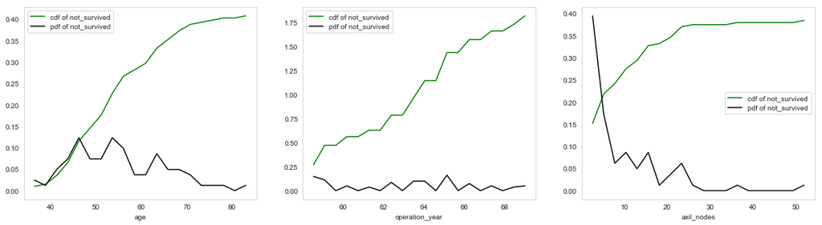

```python
# pdf and cdf of not_survived
plt.figure(figsize=(20,5))
i=1
for column in (list(haberman.columns)[:-1]):
    plt.subplot(1,3,i)
    counts, bin_edges = np.histogram(not_survived[column], bins=20, density=True)
    pdf = counts/sum(counts)
    cdf = np.cumsum(counts)
    plt.plot(bin_edges[1:], cdf, label='cdf of not_survived', color='green')
    plt.plot(bin_edges[1:], pdf, label = 'pdf of not_survived', color='black')
    plt.xlabel(column)
    plt.grid()
    plt.legend()
    i+=1
```

### Mean, Variance and Std-dev

```python
print("Means:")
print("survived")
print(np.mean(survived['age']))
print(np.mean(survived['operation_year']))
print(np.mean(survived['axil_nodes']))

print()

print("not survived")
print(np.mean(not_survived['age']))
print(np.mean(not_survived['operation_year']))
print(np.mean(not_survived['axil_nodes']))

print()

print("std:")
print(np.std(haberman['age']))
print(np.std(haberman['operation_year']))
print(np.std(haberman['axil_nodes']))
```

```
Means:
survived
52.11607142857143
62.857142857142854
2.799107142857143

not survived
53.67901234567901
62.82716049382716
7.45679012345679

std:
10.726396748570311
3.2487386178063162
7.187558302814359
```

### Median, Percentile, Quantile, IQR, MAD

```python
print("\nMedians:")
print(np.median(haberman["age"]))
print(np.median(haberman["operation_year"]))
print(np.median(haberman["axil_nodes"]))


print("\nQuantiles:")
print(np.percentile(haberman["age"],np.arange(0, 100, 25)))
print(np.percentile(haberman["operation_year"],np.arange(0, 100, 25)))
print(np.percentile(haberman["axil_nodes"], np.arange(0, 100, 25)))

print("\n90th Percentiles:")
print(np.percentile(haberman["age"],90))
print(np.percentile(haberman["operation_year"],90))
print(np.percentile(haberman["axil_nodes"], 90))

from statsmodels import robust
print ("\nMedian Absolute Deviation")
print(robust.mad(haberman["age"]))
print(robust.mad(haberman["operation_year"]))
print(robust.mad(haberman["axil_nodes"]))
```

```
Medians:
52.0
63.0
1.0

Quantiles:
[30. 44. 52. 61.]
[58. 60. 63. 66.]
[0. 0. 1. 4.]

90th Percentiles:
67.0
67.0
13.0

Median Absolute Deviation
11.860817748044816
4.447806655516806
1.482602218505602
```

Median Absolute Deviation for age shows the heterogeneity in age is more than other features

## Box Plot and Whiskers

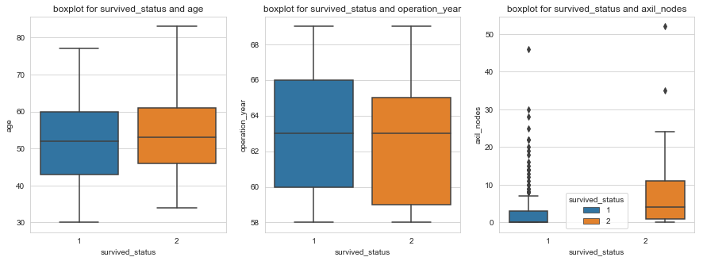

```python
plt.figure(figsize=(15,5))
plt.subplot(131)
plt.title('boxplot for survived_status and age')
sns.boxplot(x='survived_status', y='age', data=haberman)

plt.subplot(132)
plt.title('boxplot for survived_status and operation_year')
sns.boxplot(x='survived_status', y='operation_year', data=haberman)

plt.subplot(133)
plt.title('boxplot for survived_status and axil_nodes')
sns.boxplot(x='survived_status', y='axil_nodes', data=haberman, hue='survived_status')
```

1) No major conclusion could be drawn from this plots as the data points are overlapping (i.e. scattered within the same range of values).

2) The number of axil node for survival is dense from 0-5.

### Violin plots

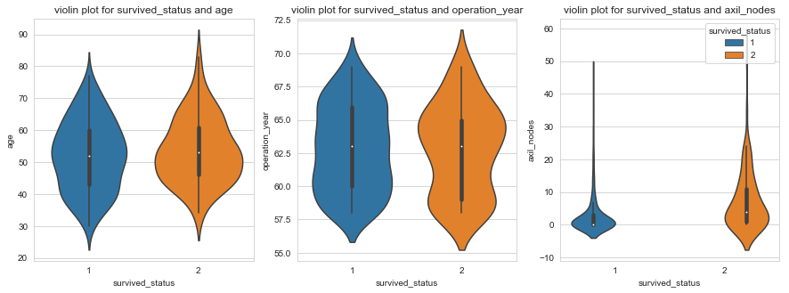

```python
plt.figure(figsize=(15,5))
plt.subplot(131)
plt.title('violin plot for survived_status and age')
sns.violinplot(x='survived_status', y='age', data=haberman)

plt.subplot(132)
plt.title('violin plot for survived_status and operation_year')
sns.violinplot(x='survived_status', y='operation_year', data=haberman)

plt.subplot(133)
plt.title('violin plot for survived_status and axil_nodes')
sns.violinplot(x='survived_status', y='axil_nodes', data=haberman, hue='survived_status')
```

None of the variable-pairs can help us find linearly separable clusters as the data is highly mixed up. We can't find any 'lines' and 'if-else' conditions to build a simple model to classify the survival status of the patient.